# Pricing Strategies of Retailers

Zhongtian and Yihao’s project

Final Project Proposal for ECON-712-008

Zhongtian Chen , Yihao Yuan https://github.com/yihao-yuan (The University of Pennsylvania)  
February 28, 2021

## Research Question

Price dispersion has long been central to a range of economic questions. For example, DellaVigna and Gentzkow (2019) investigated how uniform pricing within store chains affect store profits and social inequality. However, most papers only focused on price dispersion over stores (e.g., DellaVigna and Gentzkow (2019)) or products (e.g., Hitsch, Hortacsu, and Lin (n.d.)). Though more than 50% of the variations in transaction prices cannot be explained by differences in stores or products (Kaplan and Menzio (2015)), few have looked into price dispersion over time. Important exceptions to the lack of studies on price dispersion over time are literatures on intertemporal price discrimination (e.g., Hendel and Nevo (2013)), where stores use cyclical price changes to discriminate between searchers and non-searchers.

In this project, we would like to add to the literatures above by providing patterns of price dispersions over time. Moreover, we want to explain the reasons for a striking pattern presented in our data, that in nearly half of the promotions, the stores discounted prices below their costs. We plan to investigate existing theoretical explanations, including intertemporal price discrimination, loss leader strategy and inventory management, to explain price dispersion over time, especially the negative margins. In the end, we want to optimize the stores’ pricing strategies, and predict profit gains from the new strategies.

## Data

### Data Source

- A large shopping complex in Middle East operated in 15 countries.
- Carrefour data: 66 stores, data from January 2017 to March 2019.
  - Assortment data: product-package-date level; information includes regular price, promotion price, promotion time, quantities sold, quantities in stock, and wholesale price (cost); product-package information only available for some products (e.g., beverages). Data size: 3 billion observations, more than 800 GB.
  - Consumer data: 4.44 million consumers were in their loyalty rewards program; information includes basic demographics (gender and age).
  - Transaction data: about 29 million transactions made by loyalty program consumers per month across all stores; information includes timestamp, item purchased, price for each item, total spendings. Data size: unknown observations, about 170 GB.
- Supplementary data
  - Credit card data: transactions used by credit card issued by the owner of the shopping complex.
  - Wi-Fi data: search history of consumers when shopping within the complex/Carrefour.

### Descriptive Analyses

```
     Min.   1st Qu.    Median      Mean   3rd Qu.      Max.
-42.00000   0.04762   0.09459   0.12104   0.18974   0.99922
```

```
# A tibble: 6 x 6
  subfamily_name            mean     Q1 median     Q3       n
  <chr>                    <dbl>  <dbl>  <dbl>  <dbl>   <int>
1 Coconut Water           0.0399 0      0.0481 0.0941 2904464
2 Corn                    0.0820 0.0157 0.07   0.121  2753403
3 Cups & Straw            0.289  0.237  0.286  0.343  2349432
4 Deo men roll-on & stick 0.0990 0.0528 0.0930 0.143  3704698
5 Greek Yogurt            0.129  0.0645 0.121  0.179  4488552
6 Soda & Tonic Water      0.119  0      0.0588 0.151  2535997
```

```
# A tibble: 6 x 5
  subfamily_name            mean      Q1 median     Q3
  <chr>                    <dbl>   <dbl>  <dbl>  <dbl>
1 Coconut Water           0.0215  0.005  0.0609 0.115
2 Corn                    0.0523 -0.0156 0.0495 0.104
3 Cups & Straw            0.222   0.179  0.218  0.28
4 Deo men roll-on & stick 0.0842  0.0542 0.0812 0.128
5 Greek Yogurt            0.0961  0.0574 0.103  0.153
6 Soda & Tonic Water      0.0803  0      0.0478 0.0909
```

A discount is defined as the price lower than the regular price for a product-package. Both daily sales price and regular price are provided in the assortment data. 1.66% of the product-packages-days were in discount, and 7.14% of the product-packages were sold at discounted prices, showing evidence that consumers are price sensitive.

We compute margins of each product-package-day as $Margin = \frac{P-C}{P}$. It turns out that 4.69% (10.56%) of them are sold with negative margins (the number in the parentheses shows the result weighted by sales quantity). Strikingly, 49.48% (63.33%) of the discounted product-packages were sold with negative margins. The histograms of margins for all and discounted product-packages are presented below.

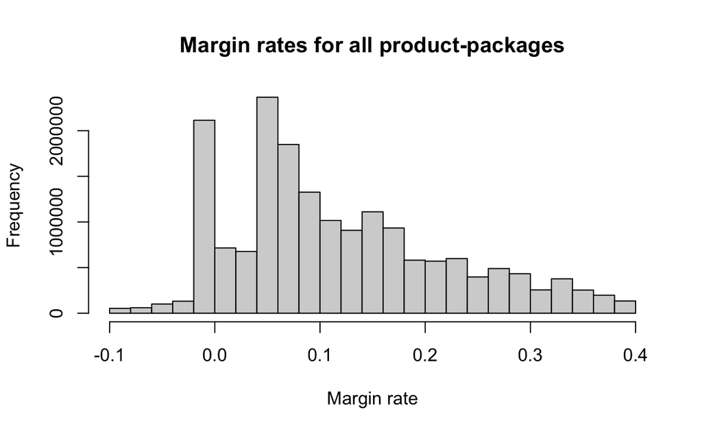

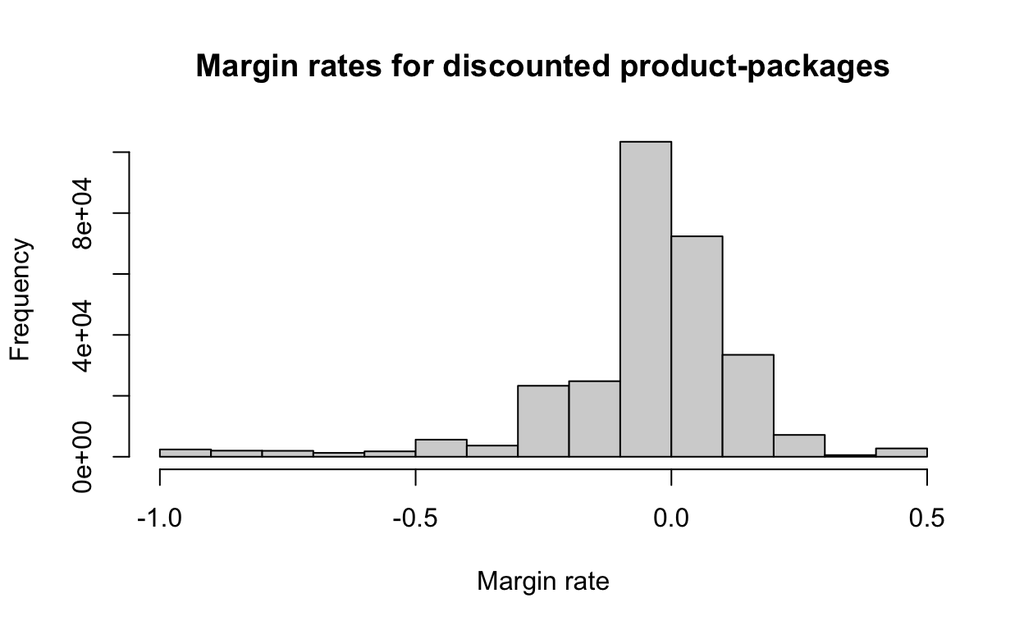

## Research Plan

DellaVigna, Stefano, and Matthew Gentzkow. 2019. “Uniform Pricing in Us Retail Chains.” *The Quarterly Journal of Economics* 134 (4). Oxford University Press: 2011–84.

Hendel, Igal, and Aviv Nevo. 2013. “Intertemporal Price Discrimination in Storable Goods Markets.” *American Economic Review* 103 (7): 2722–51.

Hitsch, Günter J, Ali Hortacsu, and Xiliang Lin. n.d. “Prices and Promotions in Us Retail Markets: Evidence from Big Data.” *Quantitative Marketing and Economics*.

Kaplan, Greg, and Guido Menzio. 2015. “The Morphology of Price Dispersion.” *International Economic Review* 56 (4). Wiley Online Library: 1165–1206.